# 第3章 推測・検定の諸問題

[R3.4] 多重検定: FDR制御

作成者：澤田真行

最終更新: 2024-09-15

ここでは、第3章の3.2節「多重検定問題とその対処」の手法を実装する。 特に、3.2.4項「偽検出率制御による検定手法」で解説した解説した多重検定問題における問題の例と、FDR制御手法を紹介する。

# 1 データ生成

## 1.1 定数の設定

まず、シミュレーションのための定数を設定する。`N`は標本サイズ、`M`は帰無仮説の数、`M_0`は正しい帰無仮説の数、`L`はシミュレーションの回数、`alpha`は有意水準である。

```r
set.seed(1)
N <- 500
M <- 60
M_0 <- 45
L <- 100
alpha <- 0.05
tau_population <- 0.2
```

## 1.2 データの生成

はじめに、シードを固定し、擬似的な無作為実験標本を生成する。一様乱数から処置割当変数を生成し、これに平均処置効果`tau_population`かけたものに 60個の独立な標準正規分布を加えたものを顕在結果とする。ただし、この時、最初の15個の顕在結果には処置効果があり、残りの45個の顕在結果には処置効果がないとする。

```r
z <-
  (
    runif(N) >= 0.5
  )
df_list_1 <-
  seq_len(M - M_0) %>%
  purrr::map(
    ~ tibble::tibble(
        z = z,
        y = rnorm(N) + tau_population * z
      )
  )
df_list_0 <-
  seq_len(M_0) %>%
  purrr::map(
    ~ tibble::tibble(
        z = z,
        y = rnorm(N)
      )
  )
df_list <-
  c(
    df_list_1,
    df_list_0
  )
```

## 1.3 検定統計量の計算

それぞれの帰無仮説を検定するために、60個の独立な線形回帰を行う。その結果の回帰係数のt値とp値を計算する。

```r
result_list_1 <-
  df_list_1 %>%
  purrr::map(
    ~ lm(
        formula = y ~ z,
        data = .
      )
  )
result_list_0 <-
  df_list_0 %>%
  purrr::map(
    ~ lm(
        formula = y ~ z,
        data = .
      )
  )
```

```r
t_list_1 <-
  result_list_1 %>%
  purrr::map(
    ~ summary(.) %>%
      coef() %>%
      .[
        "zTRUE",
        "t value"
      ]
  ) %>%
  purrr::reduce(c)
t_list_0 <-
  result_list_0 %>%
  purrr::map(
    ~ summary(.) %>%
      coef() %>%
      .[
        "zTRUE",
        "t value"
      ]
  ) %>%
  purrr::reduce(c)
```

```r
p_list_1 <-
  result_list_1 %>%
  purrr::map(
    ~ summary(.) %>%
      coef() %>%
      .[
        "zTRUE",
        "Pr(>|t|)"
      ]
  ) %>%
  purrr::reduce(c)
p_list_0 <-
  result_list_0 %>%
  purrr::map(
    ~ summary(.) %>%
      coef() %>%
      .[
        "zTRUE",
        "Pr(>|t|)"
      ]
  ) %>%
  purrr::reduce(c)
```

# 2 分析

## 2.1 FDRの計算

帰無仮説が偽である15個の検定統計量の絶対値を小さいものから順にプロットする。また、有意水準0.05に対応する棄却域を示す。

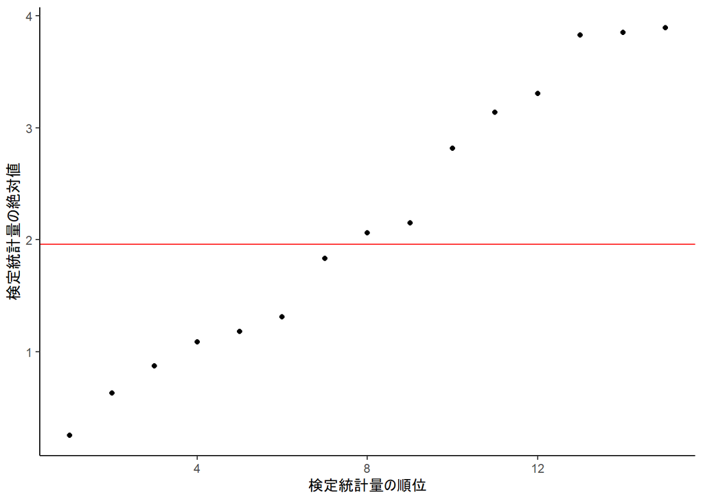

```r
ggplot(
  mapping =
    aes(
        x = seq_along(t_list_1),
        y = t_list_1 %>% abs() %>% sort()
    )
  ) +
  geom_point() +
  geom_hline(
    yintercept = abs(
      qnorm(
        1 - alpha / 2
      )
    ),
    color = "red"
  ) +
  labs(
    x = "検定統計量の順位",
    y = "検定統計量の絶対値"
  ) +
  theme_classic()
```

p値についても同様にプロットすると、以下のようになる。

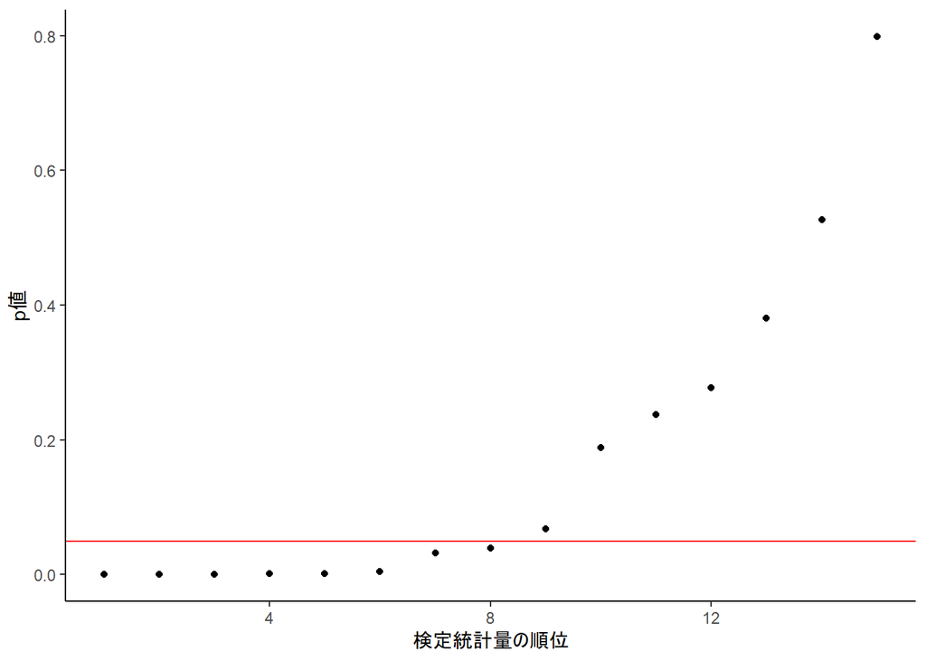

```r
ggplot(
  mapping =
    aes(
        x = seq_along(p_list_1),
        y = p_list_1 %>% sort()
    )
  ) +
  geom_point() +
  geom_hline(
    yintercept = alpha,
    color = "red"
  ) +
  labs(
    x = "検定統計量の順位",
    y = "p値"
  ) +
  theme_classic()
```

次に、帰無仮説が真である45個の検定統計量の絶対値を小さいものから順にプロットする。また、有意水準0.05に対応する棄却域を示す。

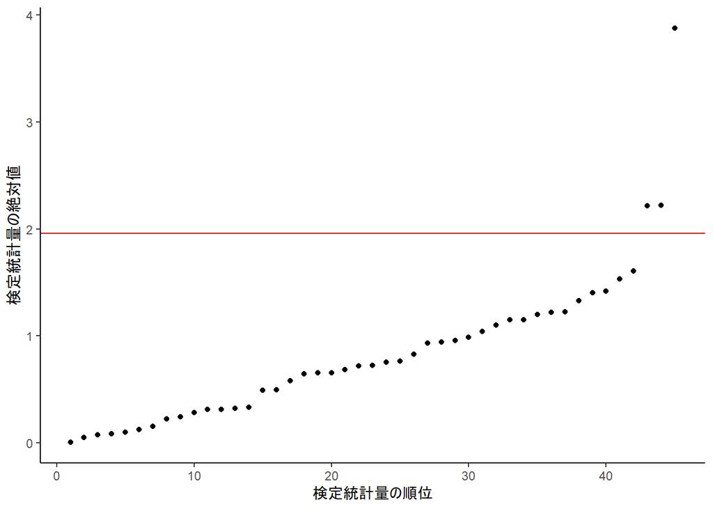

```r
ggplot(
  mapping =
    aes(
        x = seq_along(t_list_0),
        y = t_list_0 %>% abs() %>% sort()
    )
  ) +
  geom_point() +
  geom_hline(
    yintercept = abs(
      qnorm(
        1 - alpha / 2
      )
    ),
    color = "red"
  ) +
  labs(
    x = "検定統計量の順位",
    y = "検定統計量の絶対値"
  ) +
  theme_classic()
```

p値についても同様にプロットすると、以下のようになる。

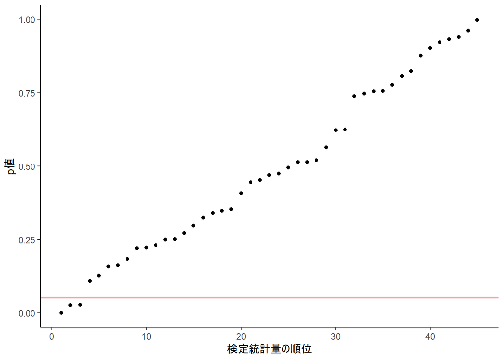

```r
ggplot(
  mapping =
    aes(
        x = seq_along(p_list_0),
        y = p_list_0 %>% sort()
    )
  ) +
  geom_point() +
  geom_hline(
    yintercept = alpha,
    color = "red"
  ) +
  labs(
    x = "検定統計量の順位",
    y = "p値"
  ) +
  theme_classic()
```

帰無仮説が偽である15個の帰無仮説のうち、正しく棄却された仮説の検定統計量は以下のとおりである。

```r
t_list_rejected_1 <-
  t_list_1[
    t_list_1 %>% abs() >
    abs(qnorm(1 - alpha / 2))
  ]
t_list_rejected_1
```

```
## [1] 3.824994 2.815632 3.848504 2.061319 2.152388 3.306946 3.137302
## [8] 3.890358
```

一方、帰無仮説が真である45個の帰無仮説のうち、誤って棄却された仮説の検定統計量は以下のとおりである。

```r
t_list_rejected_0 <-
  t_list_0[
    t_list_0 %>% abs() >
    abs(qnorm(1 - alpha / 2))
  ]
t_list_rejected_0
```

```
## [1] -3.875394 -2.214476 -2.222917
```

FDRは、棄却された帰無仮説のうち、誤って棄却された帰無仮説の割合である。具体的には、以下のように計算される。

```r
fdr <-
  t_list_rejected_0 %>% length() / (
    t_list_rejected_1 %>% length() +
    t_list_rejected_0 %>% length()
  )
fdr
```

```
## [1] 0.2727273
```

## 2.2 FDR補正

それではFDR補正する方法を適用してみよう。

### 2.2.1 Benjamini-Hochberg補正

Benjamini-Hochberg法はp値を小さい順に並べて$p^{(1)}, \cdots, p^{(M)}$としたうえで、$l = M$から初めて、$p^{(l)}$が$\alpha l/M$を下回るならば、$p^{(l)}$より小さいp値の検定を全て棄却する。

```r
p_list_sorted <-
  c(
    p_list_1,
    p_list_0
  ) %>%
  sort()
i <- M
flag_continue <- TRUE
while (
  flag_continue & i > 1
) {
  test <- p_list_sorted[i] <= (i / M) * alpha
  if (
    test
  ) {
    flag_continue <- FALSE
  }
  i <- i - 1
}
```

この手続きで棄却された帰無仮説の数と、そのp値の閾値は以下のとおりである。

```r
i
```

```
## [1] 6
```

```r
p_list_sorted[i]
```

```
## [1] 0.00180606
```

帰無仮説が偽である15個の帰無仮説のうち、正しく棄却された仮説の検定統計量は、p値が個の閾値以下のものであるから、そのp値は以下のとおりである。

```r
p_list_rejected_benjamini_hotchberg_1 <-
  p_list_1[
    p_list_1 <= p_list_sorted[i]
  ]
p_list_rejected_benjamini_hotchberg_1
```

```
## [1] 0.0001473831 0.0001343046 0.0010113291 0.0018060602 0.0001136919
```

帰無仮説が真である45個の帰無仮説のうち、誤って棄却された仮説の検定統計量は、p値が個の閾値以下のものであるから、そのp値は以下のとおりである。

```r
p_list_rejected_benjamini_hotchberg_0 <-
  p_list_0[
    p_list_0 <= p_list_sorted[i]
  ]
p_list_rejected_benjamini_hotchberg_0
```

```
## [1] 0.0001206915
```

したがって、FDRは次のとおりである。

```r
fdr_benjamini_hotchberg <-
  p_list_rejected_benjamini_hotchberg_0 %>% length() / (
    p_list_rejected_benjamini_hotchberg_1 %>% length() +
    p_list_rejected_benjamini_hotchberg_0 %>% length()
  )
fdr_benjamini_hotchberg
```

```
## [1] 0.1666667
```

先ほどのFDRは0.2727273であったのに対し、Benjamini-Hochberg法によるFDRは0.1666667とやや低下している。

この点を確認するために、データ生成過程を関数化して、100回のシミュレーションを行い、FDRの期待値を計算する。

```r
p_list_all <-
  seq_len(L) %>%
  purrr::map(
    ~ compute_p_value_mixed_effect(
        N = N,
        M = M,
        M_0 = M_0,
        seed = .
      )
  )
```

さらに、上記のBenjamini-Hochberg法によるp値の閾値の計算を関数化して、上記のシミュレーション結果に適用する。

```r
p_value_all <-
  p_list_all %>%
  purrr::map(
    ~ compute_p_value_benjamini_hotchberg(
        p_list_1 = .$p_list_1,
        p_list_0 = .$p_list_0,
        alpha = alpha
      )
  )
```

FDRの計算も関数化して、上記のシミュレーション結果に適用する。

```r
fdr_expected <-
 purrr::map2(
    p_list_all,
    p_value_all,
    ~ compute_fdr(
        p_list_1 = .x$p_list_1,
        p_list_0 = .x$p_list_0,
        p_value = .y
    )
 ) %>%
 purrr::reduce(c) %>%
 mean()

fdr_expected
```

```
## [1] 0.02511652
```

このように、期待FDRが0.0251165と0.05よりも小さい値に制御されていることがわかる。

### 2.2.2 Benjamini-Yekutieli補正

先のBenjamini-Hotchberg補正は検定間が独立な場合、あるいはある種の正の相関(Positive Regression Dependence)がある時には理論的にある程度のFDR制御ができることが示されているが、一般の相関についてはFDR制御ができない。一方で以下のBenjamini-Yakutieli法は任意の相関についてFDRを制御できることが示されている。

```r
p_list_sorted <-
  c(
    p_list_1,
    p_list_0
  ) %>%
  sort()
i <- M
flag_continue <- TRUE
while (
  flag_continue & i > 1
) {
  test <-
    (
      p_list_sorted[i] <= (i / M) * alpha / sum(1 / seq_len(M))
    )
  if (
    test
  ) {
    flag_continue <- FALSE
  }
  i <- i - 1
}
```

この手続きで棄却された帰無仮説の数と、そのp値の閾値は以下のとおりである。

```r
i
```

```
## [1] 3
```

```r
p_list_sorted[i]
```

```
## [1] 0.0001343046
```

帰無仮説が偽である15個の帰無仮説のうち、正しく棄却された仮説の検定統計量は、p値が個の閾値以下のものであるから、そのp値は以下のとおりである。

```r
p_list_rejected_benjamini_yekutieli_1 <-
  p_list_1[
    p_list_1 <= p_list_sorted[i]
  ]
p_list_rejected_benjamini_yekutieli_1
```

```
## [1] 0.0001343046 0.0001136919
```

帰無仮説が真である45個の帰無仮説のうち、誤って棄却された仮説の検定統計量は、p値が個の閾値以下のものであるから、そのp値は以下のとおりである。

```r
p_list_rejected_benjamini_yekutieli_0 <-
  p_list_0[
    p_list_0 <= p_list_sorted[i]
  ]
p_list_rejected_benjamini_yekutieli_0
```

```
## [1] 0.0001206915
```

したがって、FDRは次のとおりである。

```r
fdr_benjamini_yekutieli <-
  p_list_rejected_benjamini_yekutieli_0 %>% length() / (
    p_list_rejected_benjamini_yekutieli_1 %>% length() +
    p_list_rejected_benjamini_yekutieli_0 %>% length()
  )
fdr_benjamini_yekutieli
```

```
## [1] 0.3333333
```

100回のシミュレーションデータに適用して期待FDRを計算するとの以下の通りとなる。

```r
p_value_all <-
  p_list_all %>%
  purrr::map(
    ~ compute_p_value_benjamini_yekutieli(
        p_list_1 = .$p_list_1,
        p_list_0 = .$p_list_0,
        alpha = alpha
      )
  )
```

```r
fdr_expected <-
 purrr::map2(
    p_list_all,
    p_value_all,
    ~ compute_fdr(
        p_list_1 = .x$p_list_1,
        p_list_0 = .x$p_list_0,
        p_value = .y
    )
 ) %>%
 purrr::reduce(c) %>%
 mean()

fdr_expected
```

```
## [1] 0.002
```